# Assignment 9

Thomas Caldwell

4/24/2020

### Dataset

The dataset we are working with is Graduate School admission data.

```r
colnames(df)
```

```
## [1] "admit" "gre"   "gpa"   "rank"
```

As we can see the data includes wether or not they were admited, their gre score, their gpa, and what rank their school was.

### Exploratory plots

To first see any correlations I’m going to plot the three factors individually to acceptance.

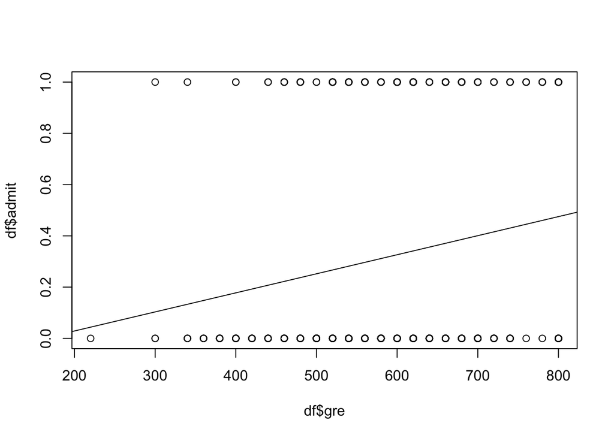

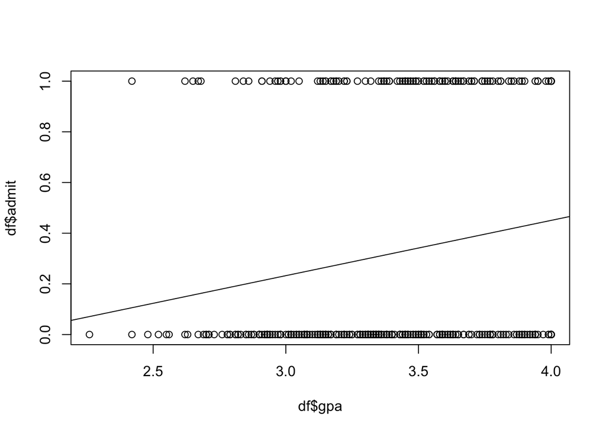

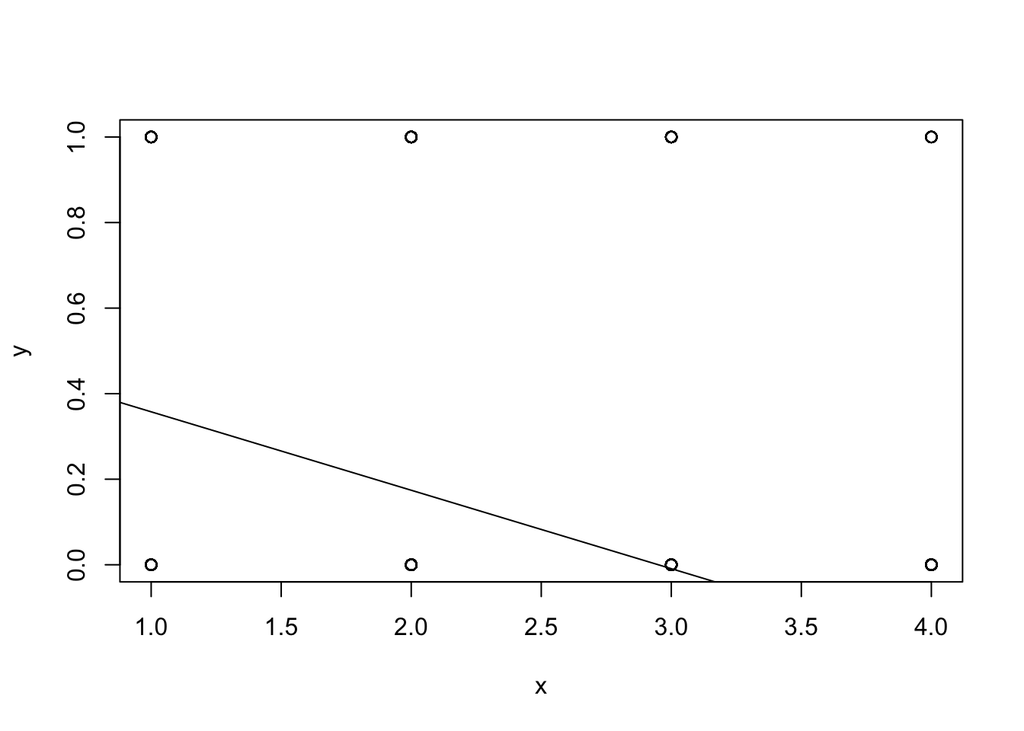

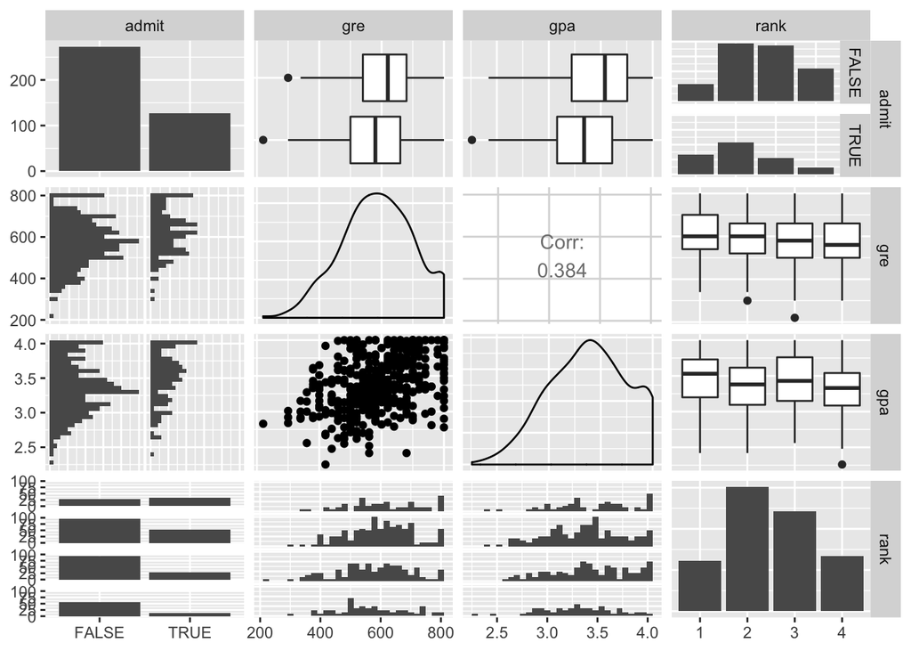

From this we can tell that gre an gpa have a positive correlation and rank and a negative but that’s because the ranks are highest to lowest.

### Models

All the factors seemed relevant, but to find the best model we will use stepAIC. We will first make a model including all the factors and then run it through to determine the best.

```r
mod = glm(admit ~ gre * gpa * rank , data=df, family=binomial(link="logit"))
step = stepAIC(mod, direction="both")
```

```
## Start:  AIC=482.39
## admit ~ gre * gpa * rank
##
##                Df Deviance    AIC
## - gre:gpa:rank  3   454.54 480.54
## <none>              450.39 482.39
##
## Step:  AIC=480.54
## admit ~ gre + gpa + rank + gre:gpa + gre:rank + gpa:rank
##
##                Df Deviance    AIC
## - gpa:rank      3   455.25 475.25
## - gre:rank      3   455.28 475.28
## <none>              454.54 480.54
## - gre:gpa       1   457.73 481.73
## + gre:gpa:rank  3   450.39 482.39
##
## Step:  AIC=475.25
## admit ~ gre + gpa + rank + gre:gpa + gre:rank
##
##            Df Deviance    AIC
## - gre:rank  3   455.77 469.77
## <none>          455.25 475.25
## - gre:gpa   1   458.24 476.24
## + gpa:rank  3   454.54 480.54
##
## Step:  AIC=469.77
## admit ~ gre + gpa + rank + gre:gpa
##
##            Df Deviance    AIC
## <none>          455.77 469.77
## - gre:gpa   1   458.52 470.52
## + gre:rank  3   455.25 475.25
## + gpa:rank  3   455.28 475.28
## - rank      3   477.85 485.85
```

The selected model:

```r
step$call
```

```
## glm(formula = admit ~ gre + gpa + rank + gre:gpa, family = binomial(link = "logit"),
##     data = df)
```

```r
step$anova
```

| Step | Df | Deviance | Resid. Df | Resid. Dev | AIC |
| --- | --- | --- | --- | --- | --- |
|  | NA | NA | 384 | 450.3858 | 482.3858 |
| - gre:gpa:rank | 3 | 4.1545628 | 387 | 454.5404 | 480.5404 |
| - gpa:rank | 3 | 0.7066923 | 390 | 455.2471 | 475.2471 |
| - gre:rank | 3 | 0.5240172 | 393 | 455.7711 | 469.7711 |

```r
mod = glm(admit ~ gre + gpa + rank + gre:gpa, data=df, family=binomial(link="logit"))
```

### Testing the model

I split the dataframe into two groups and then setup the model with one and had it add predictions to the other. Then it was graphed with all the factors to visualize its usefulness.

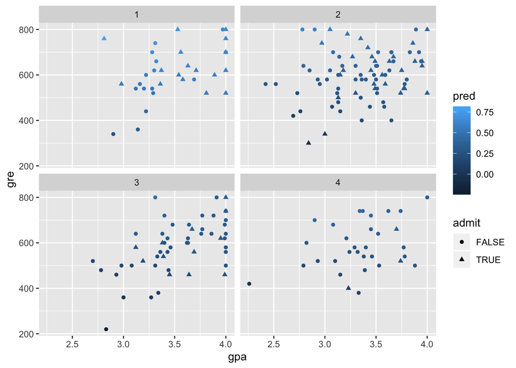

```r
set.seed(666)
set = caret::createDataPartition(df$admit, p=.5)
set = set$Resample1
train = df[set,]
test = df[-set,]
mod_cv = lm(data=train, formula = formula(step$call))
test$pred = predict(mod_cv, test, type = "response")


ggplot(test, aes(x = gpa, y = gre, shape = admit))+
  geom_point(aes(y = gre ,colour = pred))+
  facet_wrap(~rank)
```